# Project: Investigating the TMDB MOVIES Dataset

# What is the relationship between the budget and the profit?

```python
# Cheking the relationship between budget and profit using correlation

tmdb_data[['budget', 'profit']].corr()
```

|  | budget | profit |
| --- | --- | --- |
| budget | 1.000000 | 0.526818 |
| profit | 0.526818 | 1.000000 |

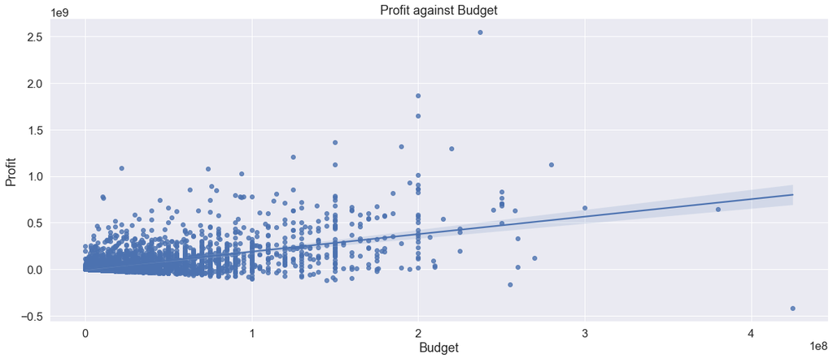

```python
plot_reg('budget', 'profit', tmdb_data, 'Budget', 'Profit', 'Profit against Budget')
```

As shown from the plot above, there is positive correlation between the budget and profit features of the dataset. This shows that there high budget is associated with high profit

# What is the relationship between average vote and the profit?

```python
# Cheking the relationship between average vote and profit using correlation

tmdb_data[['vote_average', 'profit']].corr()
```

|  | vote_average | profit |
| --- | --- | --- |
| vote_average | 1.000000 | 0.259435 |
| profit | 0.259435 | 1.000000 |

From the table, the correlation between the average vote and the profit earned is about **0.259435**, this depicts a weak relationship between the two variables

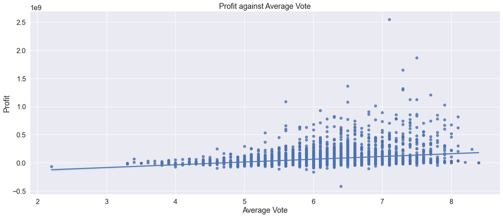

```python
plot_reg('vote_average', 'profit', tmdb_data, 'Average Vote', 'Profit', 'Profit against Average Vote')
```

As shown from the plot above, there is a weak positive correlation between the vote average and profit features of the dataset. This shows there is little association between the average vote and the profit earned by a movie.

# Who was the most frequent actor?

```python
tmdb_data['cast'] = tmdb_data['cast'].apply(lambda x: x.split('|'))
```

```python
from collections import defaultdict

actor_appearances = defaultdict(int)

for actor_list in tmdb_data['cast'].values:
    for actor in actor_list:
        actor_appearances[actor]+=1

sorted_actor_appearances = dict(sorted(actor_appearances.items(), key = lambda x: x[1], reverse=True))
```

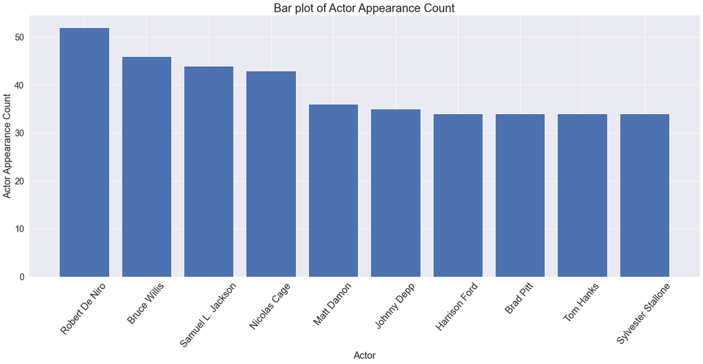

```python
plot_bar_from_dict(sorted_actor_appearances, 'Actor', 'Actor Appearance Count', 'Bar plot of Actor Appearance Count', 'list')
```

From the plot above, Robert De Niro acted in most movies followed by Bruce Wills and Samuel L. Jackson

# Conclusions

### Limitations

Some assumptions were made during the analysis which may not make the results of the analysis 100 percent accurate. For instance, it was assumed that movies with 0 value of budget or revenue were not released and so they not included in our analysis, also null values were replaced with "Unknown". Nonetheless, the overall results of the analysis shows the general trend of released movies